# Personal Activity Report

Rodica Fazakas

Sunday, July 26, 2015

## Part 1

In this section we process the data available for this project, we fit a predictive model using Random Forest algorithm and we measure its performance.

## Data Preparation

First, we download the training and the test data for this project and clean them by dropping those variables which have missing observations and a couple of other non relevant variables. We are left with a training dataset containing 19,622 observations and 53 variables and a test set with 20 observations and 53 variables.

```r
library(caret)
library(randomForest)
```

```r
library(rpart)
library(rpart.plot)

set.seed(100000)

# Get the data
setInternet2(TRUE)  # set the R_WIN_INTERNET2 to TRUE
download.file('https://d396qusza40orc.cloudfront.net/predmachlearn/pml-training.csv','pml-training.csv')
download.file('https://d396qusza40orc.cloudfront.net/predmachlearn/pml-testing.csv','pml-test.csv' )

training <- read.csv('pml-training.csv', na.strings=c("NA","#DIV/0!", ""))
testing  <- read.csv('pml-test.csv' , na.strings=c("NA", "#DIV/0!", ""))

# Clean the data
training <- training[, colSums(is.na(training)) == 0]
classe <- training$classe
trainout <- grepl("^X|timestamp|window", names(training))
training <- training[, !trainout]
newtraining <- training[, sapply(training, is.numeric)]
newtraining$classe <- classe

testing <- testing[, colSums(is.na(testing)) ==0 ]
testout <- grepl("^X|timestamp|window", names(testing))
testing <- testing[, !testout]
newtesting <- testing[, sapply(testing, is.numeric)]
```

## Partition the data

We divide the data into 60% training and 40% testing sets. We obtain a training set of 11,776 observations and a validation set of 7,846 observations.

```r
# Partition the data
inTrain <- createDataPartition(y=newtraining$classe, p=0.6, list=FALSE)
myTraining <- newtraining[inTrain,]
myTesting <- newtraining[-inTrain,]
```

# Data Modelling

We use Random Forest algorithm to fit a predictive model for exercising. We use 5-fold cross validation when applying the algorithm. We find that the most important variables in predicting the manner of exercising, as captured bt the variable “classe” are roll-belt, yaw-belt and magnet-dumbbell-z“.

```r
# Data Modelling
ctrl <- trainControl(method = "cv", 5)
modrf <- train(classe ~ ., data=myTraining, method="rf", trControl=ctrl)
modrf
```

```
## Random Forest
##
## 11776 samples
##    52 predictor
##     5 classes: 'A', 'B', 'C', 'D', 'E'
##
## No pre-processing
## Resampling: Cross-Validated (5 fold)
##
## Summary of sample sizes: 9421, 9422, 9420, 9420, 9421
##
## Resampling results across tuning parameters:
##
##   mtry  Accuracy   Kappa      Accuracy SD  Kappa SD
##    2    0.9898094  0.9871077  0.001504681  0.001902419
##   27    0.9897249  0.9870011  0.002023172  0.002559538
##   52    0.9851393  0.9811975  0.002863975  0.003624911
##
## Accuracy was used to select the optimal model using  the largest value.
## The final value used for the model was mtry = 2.
```

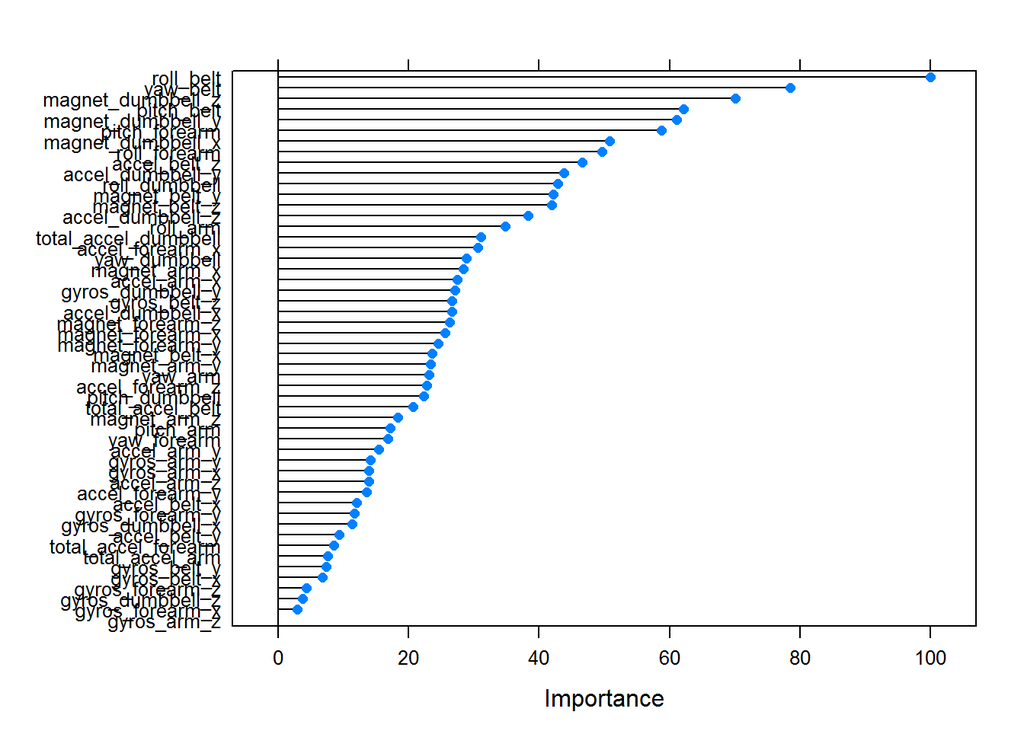

```r
plot(varImp(modrf))
```

Then we predict this modeling on the validation data set. We find the accuracy of the prediction model to be 99.2% and the out-of-sample error to be 0.77%.

```r
# Estimate the model on the validation test
predictRf <- predict(modrf, myTesting)
confusionMatrix(myTesting$classe, predictRf)
```

```
## Confusion Matrix and Statistics
##
##           Reference
## Prediction    A    B    C    D    E
##          A 2232    0    0    0    0
##          B   10 1504    4    0    0
##          C    0    7 1359    2    0
##          D    0    0   33 1251    2
##          E    0    0    0    3 1439
##
## Overall Statistics
##
##                Accuracy : 0.9922
##                  95% CI : (0.99, 0.994)
##     No Information Rate : 0.2858
##     P-Value [Acc > NIR] : < 2.2e-16
##
##                   Kappa : 0.9902
##  Mcnemar's Test P-Value : NA
##
## Statistics by Class:
##
##                      Class: A Class: B Class: C Class: D Class: E
## Sensitivity            0.9955   0.9954   0.9735   0.9960   0.9986
## Specificity            1.0000   0.9978   0.9986   0.9947   0.9995
## Pos Pred Value         1.0000   0.9908   0.9934   0.9728   0.9979
## Neg Pred Value         0.9982   0.9989   0.9943   0.9992   0.9997
## Prevalence             0.2858   0.1926   0.1779   0.1601   0.1837
## Detection Rate         0.2845   0.1917   0.1732   0.1594   0.1834
## Detection Prevalence   0.2845   0.1935   0.1744   0.1639   0.1838
## Balanced Accuracy      0.9978   0.9966   0.9861   0.9954   0.9991
```

```r
accuracy <- postResample(predictRf, myTesting$classe)
accuracy
```

```
##  Accuracy     Kappa
## 0.9922253 0.9901641
```

```r
error <- 1 - as.numeric(confusionMatrix(myTesting$classe, predictRf)$overall[1])
error
```

```
## [1] 0.007774662
```

## Part 2

In this section we apply the model to the original testing data set.

```r
predict2 <- predict(modrf, newtesting[, -length(names(newtesting))], type = "raw")
pml_write_files = function(x){
  n = length(x)
  for(i in 1:n){
    filename = paste0("problem_id_",i,".txt")
    write.table(x[i],file=filename,quote=FALSE,row.names=FALSE,col.names=FALSE)
  }
}
pml_write_files(predict2)
```

## Appendix

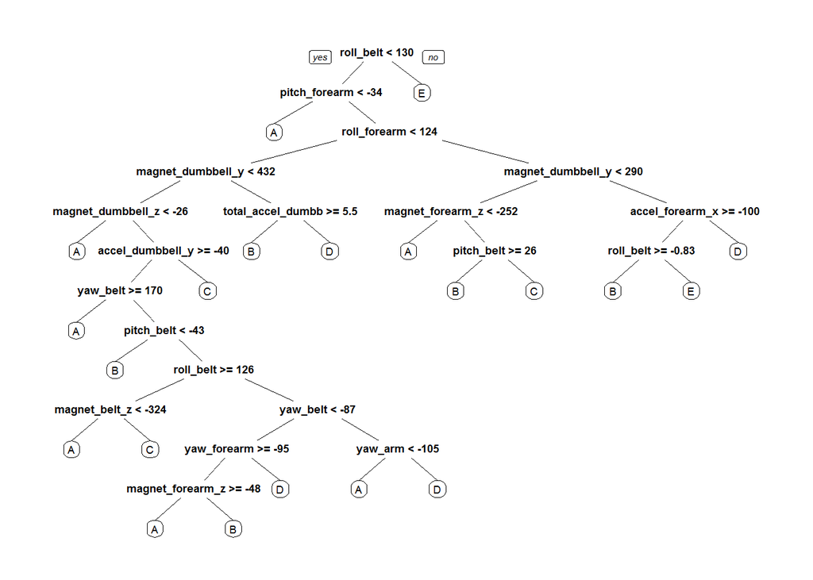

```r
# Decision Tree Vizualization
treeModel <- rpart(classe ~ ., data=myTraining, method="class")
prp(treeModel)
```